# Final Exam Markdown: Group 1

The fall 2020 IST722 final exam has two parts: a statistical analysis you develop in class and a report that you write on your own time. The first part, which you are working on right now, involves using this Markdown file to produce all of the diagnostics, graphs, and statistical output you will need for your report.

The **Knit** button at the top of the code window will generate an html file that includes both content as well as the output of any embedded R code chunks within this document. When you open this html file in a browser, you will be able to save it as a pdf file for submission to Blackboard. The file you submit to Blackboard must contain all of the output that you will use in your report. Any questions you answer with results or graphics not appearing in your PDF will not receive credit.

This initial code block opens the file and produces basic diagnostics. Make sure you have set the working directory and the file name correctly.

```r
# First, set the working directory to wherever you have stored your data file.
# setwd("~/Downloads")
# Already stored the markdown file in the same directory. So, I won't be setting the
# working directory

# In this block, modify the file name of the Rdata file to match the name of
# the file you downloaded from Blackboard. Change the 1 to whatever number you have
load("datasets15.RData")

# If you can't get that to work, comment out the previous line and try file.choose() to select
# your data file using a file selection dialog:
#
# load(file.choose())

# Now make sure that the two datasets you will be using are available.
str(usVaccines)
```

```
##  Time-Series [1:38, 1:5] from 1980 to 2017: 83 84 83 84 84 85 88 88 89 81 ...
##  - attr(*, "dimnames")=List of 2
##   ..$ : NULL
##   ..$ : chr [1:5] "DTP1" "HepB_BD" "Pol3" "Hib3" ...
```

```r
dim(usVaccines)
```

```
## [1] 38  5
```

```r
str(districts)
```

```
## 'data.frame':    700 obs. of  12 variables:
##  $ DistrictName    : Factor w/ 846 levels "ABC Unified",..: 2 593 504 213 110 703 51 635 84 459 ...
##  $ WithoutDTP      : num  8 23 9 15 5 14 9 3 18 38 ...
##  $ WithoutPolio    : num  11 24 9 15 5 11 9 3 15 38 ...
##  $ WithoutMMR      : num  6 25 9 15 4 11 10 3 20 38 ...
##  $ WithoutHepB     : num  3 13 9 15 4 11 8 3 2 38 ...
##  $ PctUpToDate     : num  87 71 91 85 95 84 89 96 76 63 ...
##  $ DistrictComplete: logi  TRUE TRUE TRUE TRUE TRUE TRUE ...
##  $ PctBeliefExempt : num  1 7 7 5 3 5 2 3 0 31 ...
##  $ PctChildPoverty : num  13 23 25 25 8 7 36 19 27 4 ...
##  $ PctFamilyPoverty: num  10 16 13 5 4 4 27 8 14 9 ...
##  $ Enrolled        : num  71 447 290 20 405 37 259 290 66 16 ...
##  $ TotalSchools    : num  1 8 3 1 4 2 3 3 1 1 ...
```

```r
dim(districts)
```

```
## [1] 700  12
```

## Plotting the Time Series Data

A basic time series plot can be valuable for examining trends, periodicity, and other aspects of a time series. You don’t necessarily need to include this plot in your report, particularly because you only care about vaccination levels in the most recent few years.

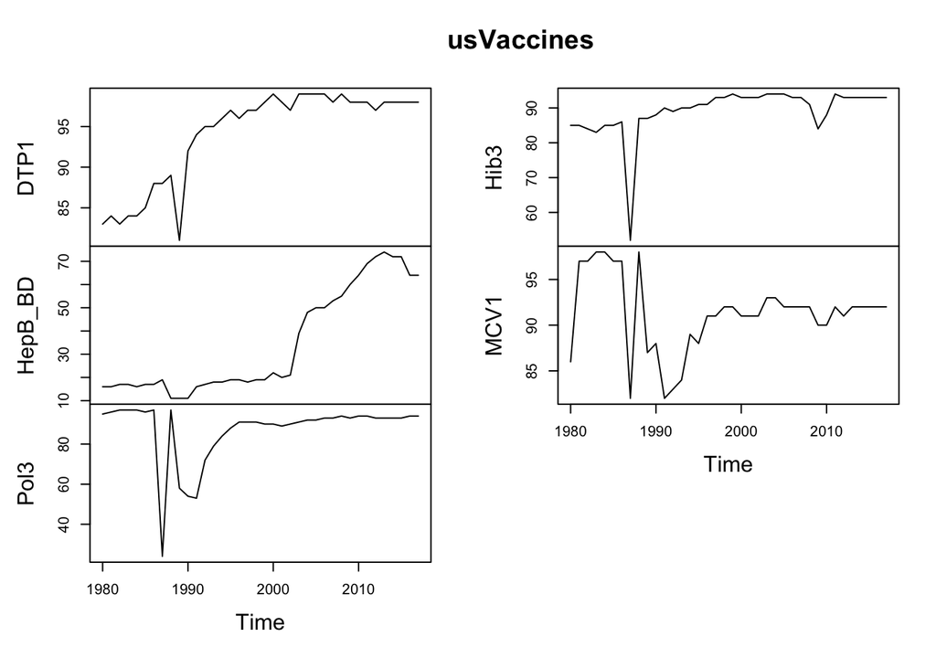

```r
plot(usVaccines)
```

```r
# Key to abbreviations (from WHO)
# DTP - Diptheria, Tetanus, Pertussis
# HepB_BD - Hepatitis B, Birth Dose
# Pol3 - Inactivated polio vaccine
# Hib3 - Haemophilus influenza type B vaccine
# MCV - Measles-containing-vaccine first-dose
```

## Time Series Autocorrelation

One of the most basic diagnostics for time series is an autocorrelation plot. One of the exam questions asks you to interpret these plots. You need not modify this block of code, as it produces all five of the plots you need.

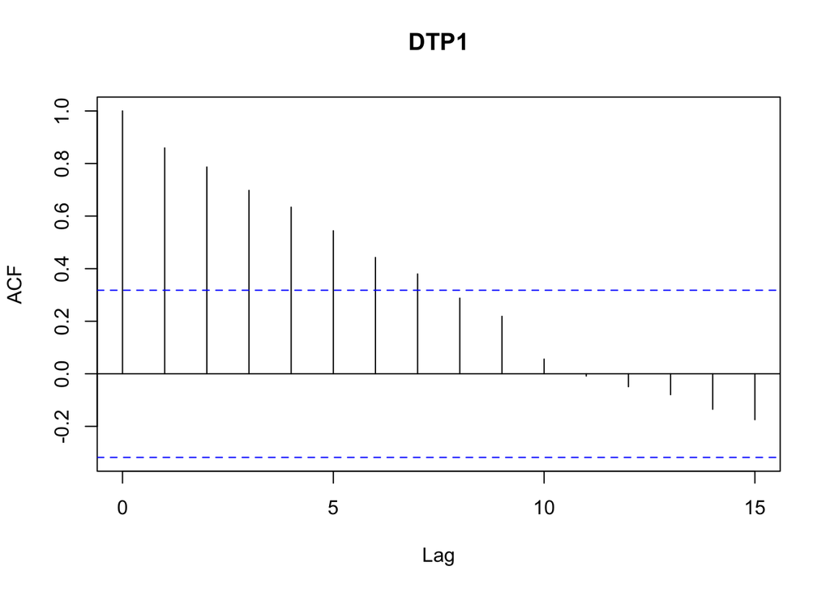

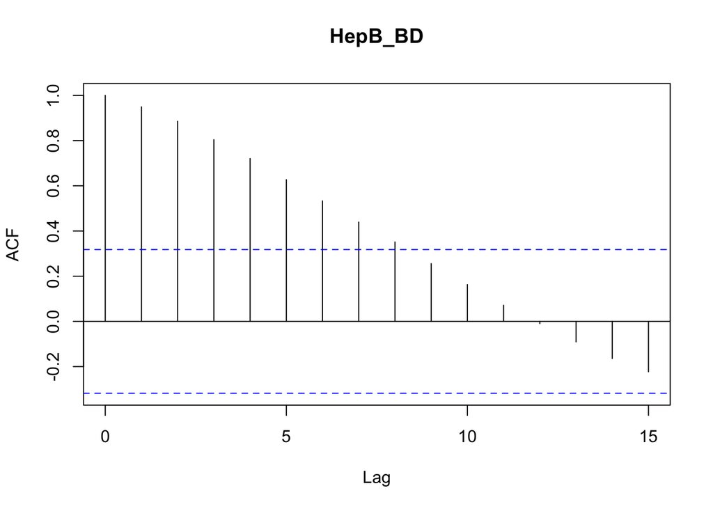

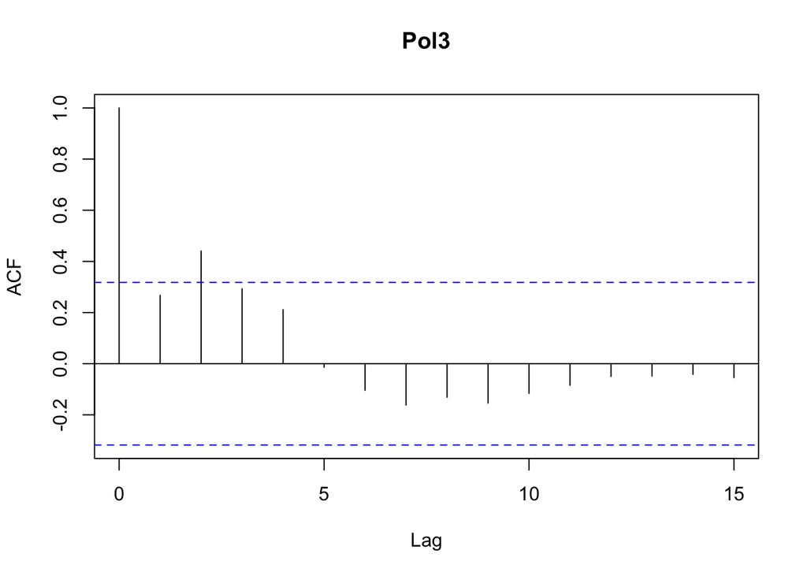

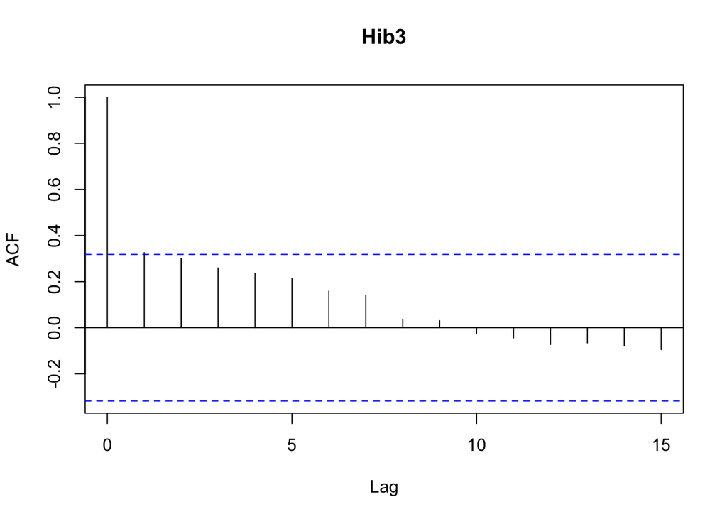

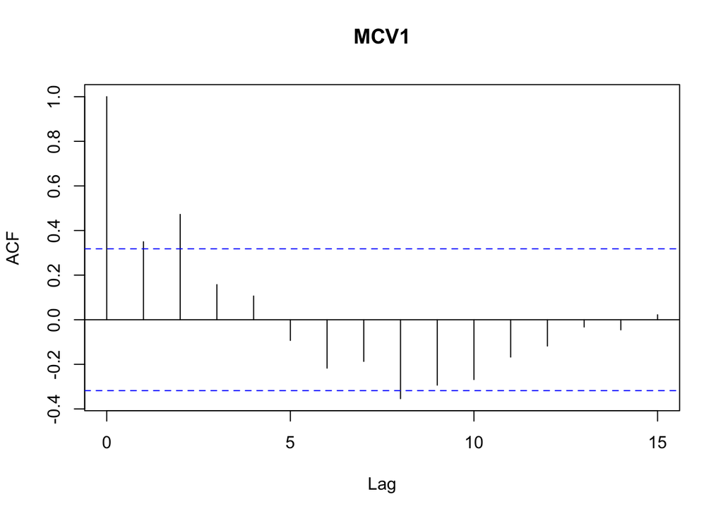

```r
# This runs an ACF on each of the five time series
for (i in 1:5) {
  acf(usVaccines[,i], main=attr(usVaccines,"dimnames")[[2]][i])
}
```

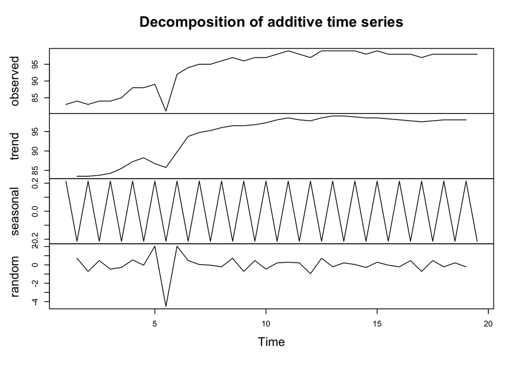

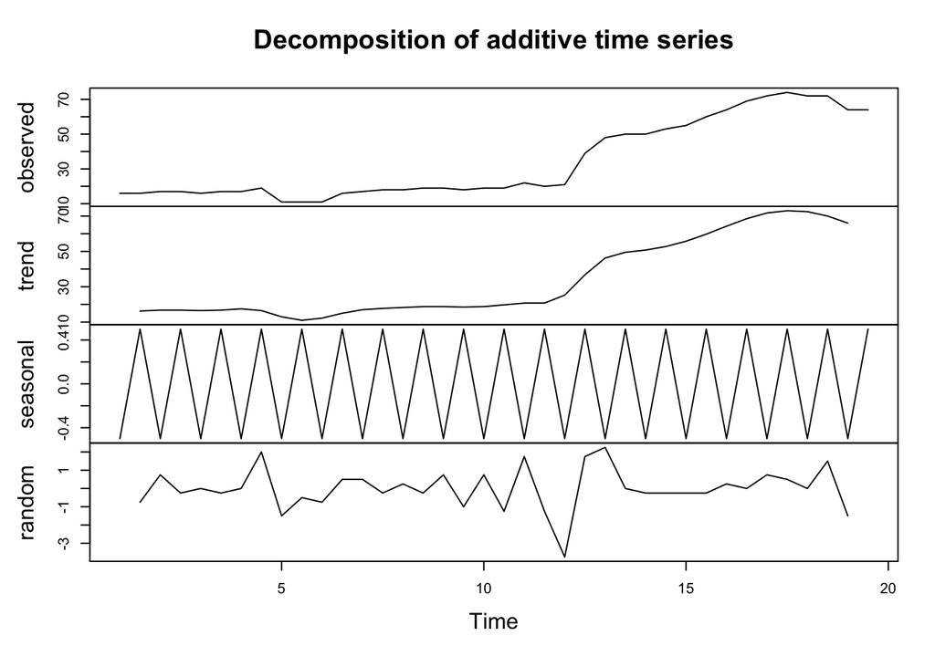

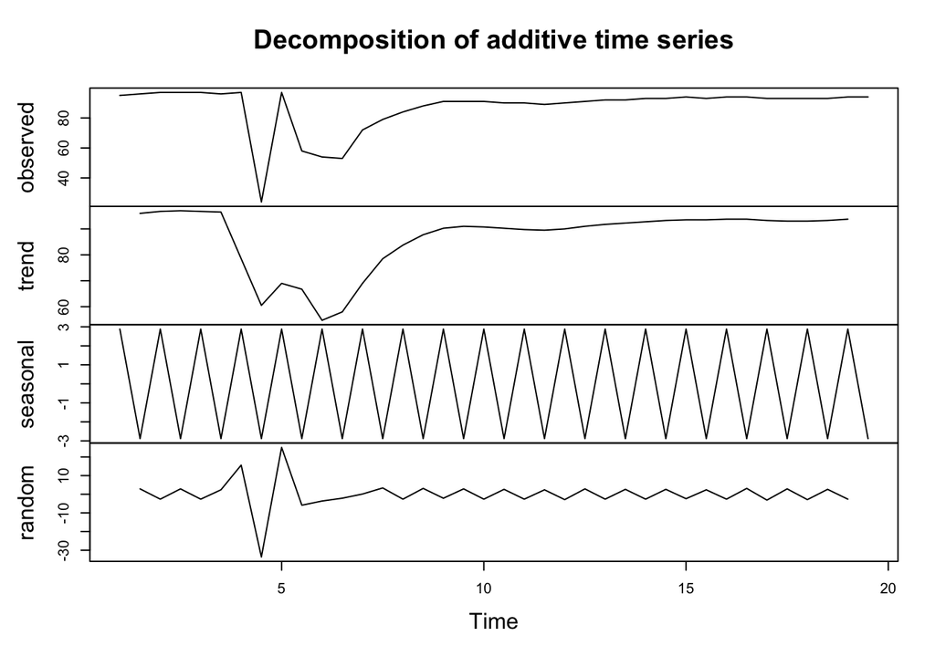

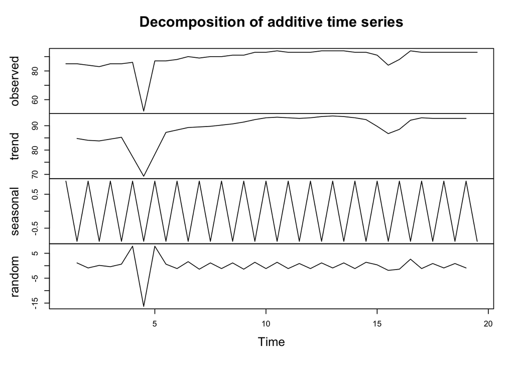

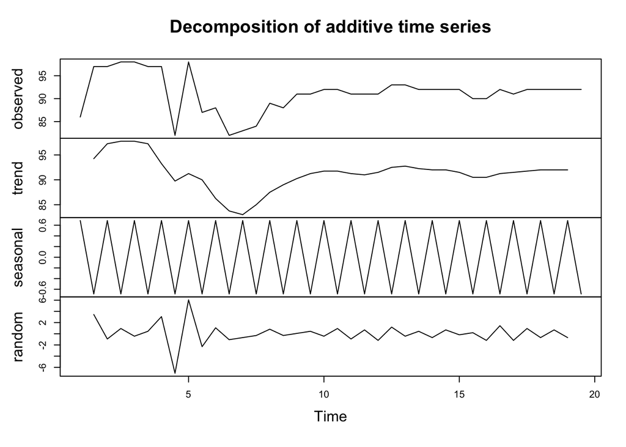

```r
for (i in 1:5) {
  plot(decompose(ts(usVaccines[, i], frequency = 2)))
}
```

## Time Series Changepoint Analysis of Means

This code calculates a changepoint analysis of means that is designed to find the last mean changepoint within each of the five series. As long as you have the changepoint package installed, there should be no need to modify this code.

```r
library(changepoint)
# This finds the final mean changepoint for each time series
print("Last mean changepoint for each time series:")
```

```
## [1] "Last mean changepoint for each time series:"
```

```r
for (i in 1:5) {
  print(attr(usVaccines,"dimnames")[[2]][i])
  print(changepoint::cpt.mean(rev(usVaccines[,i]), method="AMOC")@cpts[1])
}
```

```
## [1] "DTP1"
## [1] 28
## [1] "HepB_BD"
## [1] 14
## [1] "Pol3"
## [1] 23
## [1] "Hib3"
## [1] 30
## [1] "MCV1"
## [1] 31
```

## Time Series Subsetting

You will be calibrating your district-by-district vaccine results by comparing to the U.S. mean level of vaccination during recent years. Subset the time series data to only include the most recent years during which all vaccine mean levels were stable. Use the changepoint output from the previous step to make this judgment call. Set the value of startPoint to the most appropriate starting point within the 38 year period of the time series data. Then calculate the mean level for each vaccination during that time period.

Optionally add a bar plot that puts all of the mean vaccination levels into the same graphic.

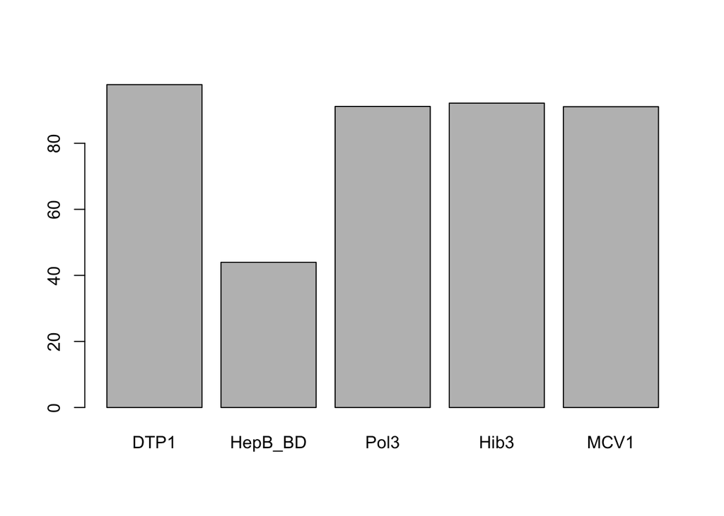

```r
startPoint <- 14 # Change the starting point for calculating a mean of recent observations only.
# Choose the most reasonable value by looking at the results of the previous code block.

# Now calculate the mean vaccination level during recent years for
# each type of vaccine.
mean_vacc <- apply(usVaccines[startPoint:38,], MARGIN=2, FUN=mean)

# Optionally add a barplot() to display these means.
barplot(mean_vacc)
```

That’s the end of the analysis of the usVaccines data. Next, you will conduct diagnostics on your main dataset, the district by district results for a random sample of n=700 California school districts. Refer to the exam specification for information on the meaning of each variable in your data set.

## Descriptive Statistics for Later Use

Clients expect basic descriptive statistics on the major variables of importance. Descriptives may also be important in guiding your analyses. The code below produces a summary of the data set, but you may also want to compute some other statistics that do not appear in the output of summary().

```r
summary(districts)
```

```
##                             DistrictName   WithoutDTP     WithoutPolio
##  ABC Unified                      :  1   Min.   : 0.00   Min.   : 0.000
##  Ackerman Charter                 :  1   1st Qu.: 3.00   1st Qu.: 3.000
##  Alameda Unified                  :  1   Median : 7.00   Median : 6.000
##  Albany City Unified              :  1   Mean   :10.00   Mean   : 9.533
##  Alexander Valley Union Elementary:  1   3rd Qu.:13.25   3rd Qu.:13.000
##  Alhambra Unified                 :  1   Max.   :66.00   Max.   :66.000
##  (Other)                          :694
##    WithoutMMR      WithoutHepB      PctUpToDate    DistrictComplete
##  Min.   : 0.000   Min.   : 0.000   Min.   : 26.0   Mode :logical
##  1st Qu.: 3.000   1st Qu.: 2.000   1st Qu.: 84.0   FALSE:43
##  Median : 6.000   Median : 4.000   Median : 92.0   TRUE :657
##  Mean   : 9.984   Mean   : 7.541   Mean   : 88.1
##  3rd Qu.:13.000   3rd Qu.:10.000   3rd Qu.: 96.0
##  Max.   :68.000   Max.   :69.000   Max.   :100.0
##
##  PctBeliefExempt  PctChildPoverty PctFamilyPoverty    Enrolled
##  Min.   : 0.000   Min.   : 2.00   Min.   : 0.00    Min.   :   10.0
##  1st Qu.: 0.750   1st Qu.:13.00   1st Qu.: 5.00    1st Qu.:   55.0
##  Median : 2.000   Median :21.00   Median :10.00    Median :  223.0
##  Mean   : 5.487   Mean   :22.32   Mean   :11.47    Mean   :  634.8
##  3rd Qu.: 6.000   3rd Qu.:29.00   3rd Qu.:16.00    3rd Qu.:  684.2
##  Max.   :60.000   Max.   :72.00   Max.   :47.00    Max.   :54238.0
##
##   TotalSchools
##  Min.   :  1.000
##  1st Qu.:  1.000
##  Median :  3.000
##  Mean   :  7.307
##  3rd Qu.:  8.000
##  Max.   :582.000
##
```

```r
# Add any additional descriptive statistics that you want to view now or later.

# This produces a complete correlation matrix, rounded to two decimal digits
round(cor(districts[,-1]),2)
```

```
##                  WithoutDTP WithoutPolio WithoutMMR WithoutHepB PctUpToDate
## WithoutDTP             1.00         0.98       0.97        0.89       -0.96
## WithoutPolio           0.98         1.00       0.96        0.90       -0.94
## WithoutMMR             0.97         0.96       1.00        0.89       -0.97
## WithoutHepB            0.89         0.90       0.89        1.00       -0.85
## PctUpToDate           -0.96        -0.94      -0.97       -0.85        1.00
## DistrictComplete      -0.06        -0.06      -0.05       -0.02        0.06
## PctBeliefExempt        0.80         0.82       0.78        0.92       -0.72
## PctChildPoverty       -0.21        -0.21      -0.21       -0.23        0.21
## PctFamilyPoverty      -0.26        -0.26      -0.25       -0.28        0.26
## Enrolled              -0.07        -0.07      -0.07       -0.08        0.06
## TotalSchools          -0.05        -0.05      -0.06       -0.06        0.04
##                  DistrictComplete PctBeliefExempt PctChildPoverty
## WithoutDTP                  -0.06            0.80           -0.21
## WithoutPolio                -0.06            0.82           -0.21
## WithoutMMR                  -0.05            0.78           -0.21
## WithoutHepB                 -0.02            0.92           -0.23
## PctUpToDate                  0.06           -0.72            0.21
## DistrictComplete             1.00           -0.01           -0.06
## PctBeliefExempt             -0.01            1.00           -0.19
## PctChildPoverty             -0.06           -0.19            1.00
## PctFamilyPoverty            -0.09           -0.24            0.86
## Enrolled                    -0.19           -0.09            0.03
## TotalSchools                -0.21           -0.08            0.02
##                  PctFamilyPoverty Enrolled TotalSchools
## WithoutDTP                  -0.26    -0.07        -0.05
## WithoutPolio                -0.26    -0.07        -0.05
## WithoutMMR                  -0.25    -0.07        -0.06
## WithoutHepB                 -0.28    -0.08        -0.06
## PctUpToDate                  0.26     0.06         0.04
## DistrictComplete            -0.09    -0.19        -0.21
## PctBeliefExempt             -0.24    -0.09        -0.08
## PctChildPoverty              0.86     0.03         0.02
## PctFamilyPoverty             1.00     0.04         0.03
## Enrolled                     0.04     1.00         0.99
## TotalSchools                 0.03     0.99         1.00
```

```r
round(cor(districts[,2:5]),2)
```

```
##              WithoutDTP WithoutPolio WithoutMMR WithoutHepB
## WithoutDTP         1.00         0.98       0.97        0.89
## WithoutPolio       0.98         1.00       0.96        0.90
## WithoutMMR         0.97         0.96       1.00        0.89
## WithoutHepB        0.89         0.90       0.89        1.00
```

```r
colMeans(districts[2:5])
```

```
##   WithoutDTP WithoutPolio   WithoutMMR  WithoutHepB
##    10.000000     9.532857     9.984286     7.541429
```

```r
aggregate(districts[,2:5],by=list(districts$DistrictName), mean)
```

[output not shown]

[output cut: 1387 more lines]

```r
mean(districts$PctUpToDate)
```

```
## [1] 88.09571
```

## Plotting Histograms as Diagnostics

Most reports that you create for clients will NOT benefit from including histograms because histograms are very low level and rarely communicate much of interest. Nonetheless, you should look at them yourself to make sure you understand your data. Add any additional histograms that you wish to view.

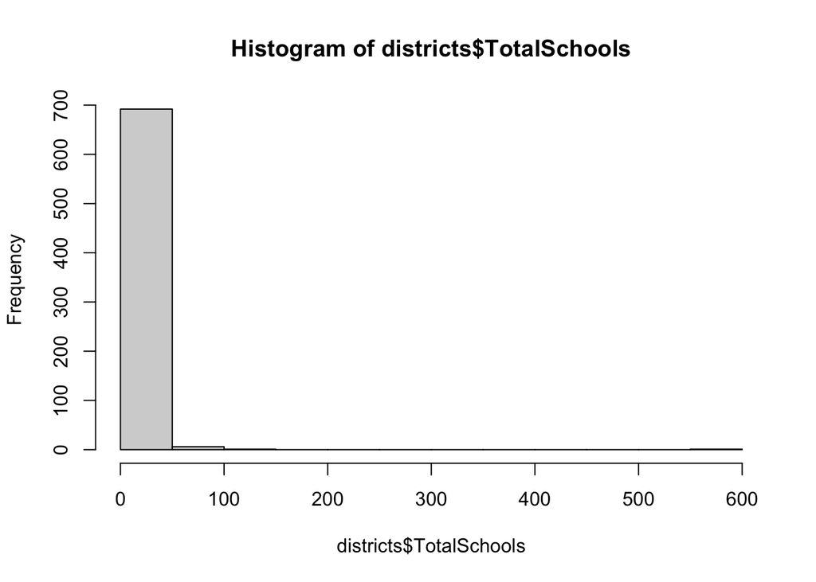

```r
hist(districts$TotalSchools)
```

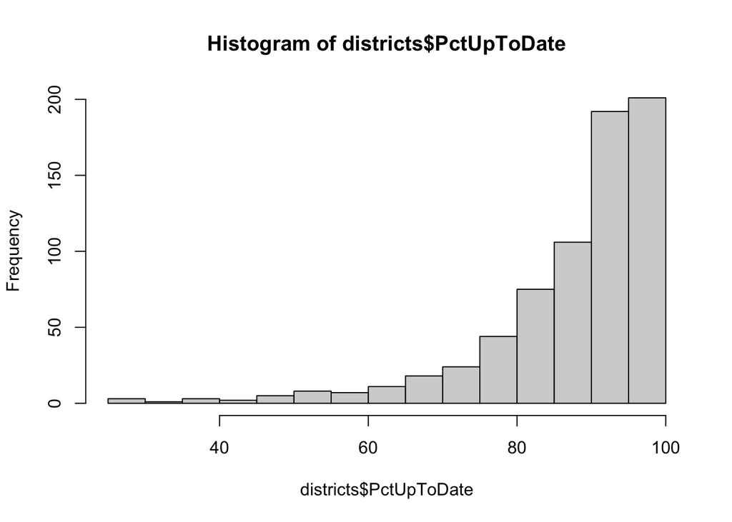

```r
# Add any additional histograms that you want to view now or later.
hist(districts$PctUpToDate)
```

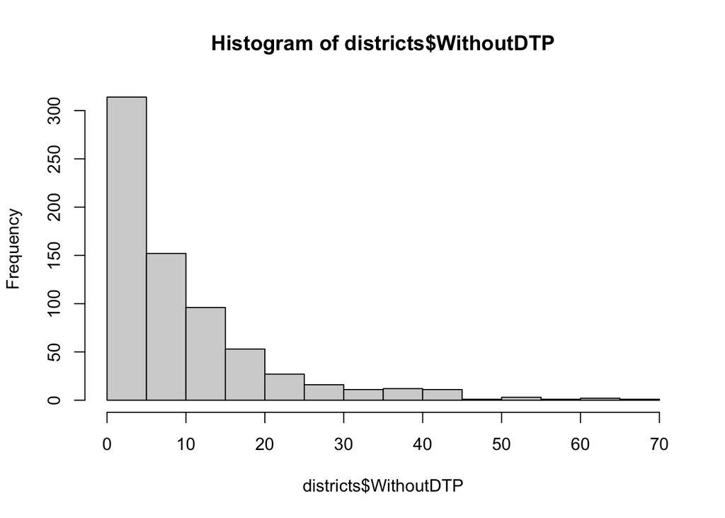

```r
hist(districts$WithoutDTP)
```

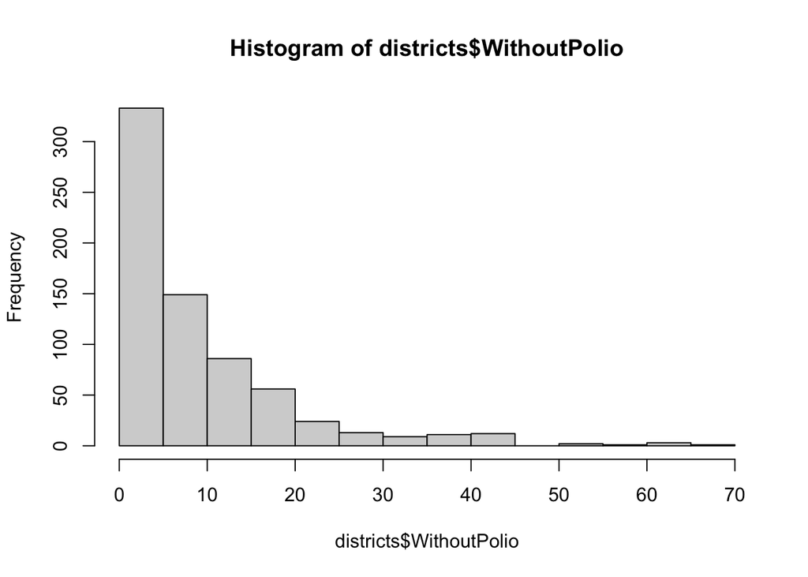

```r
hist(districts$WithoutPolio)
```

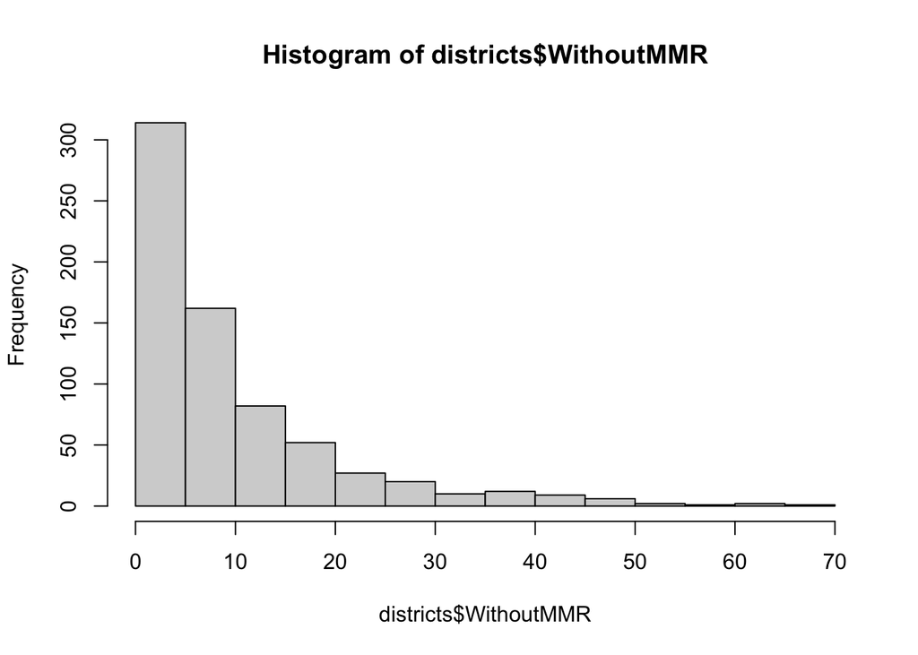

```r
hist(districts$WithoutMMR)
```

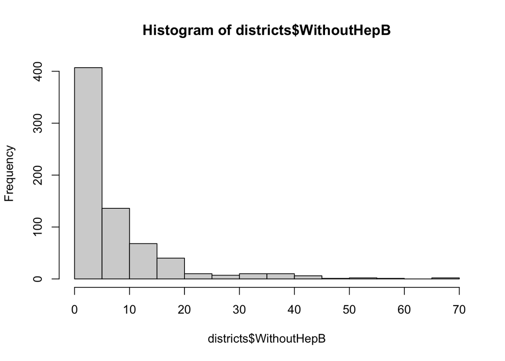

```r
hist(districts$WithoutHepB)
```

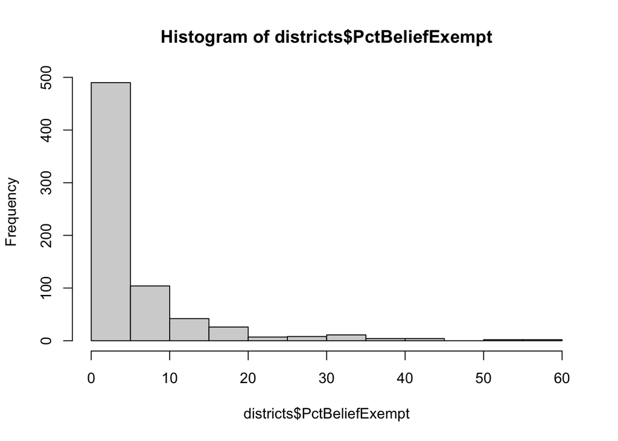

```r
hist(districts$PctBeliefExempt) # 2
```

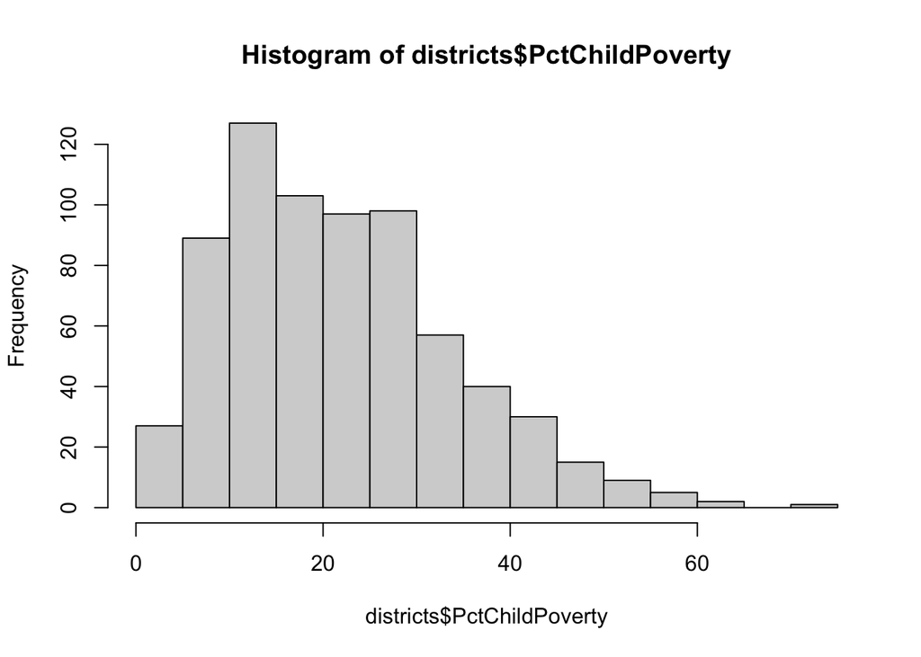

```r
hist(districts$PctChildPoverty)
```

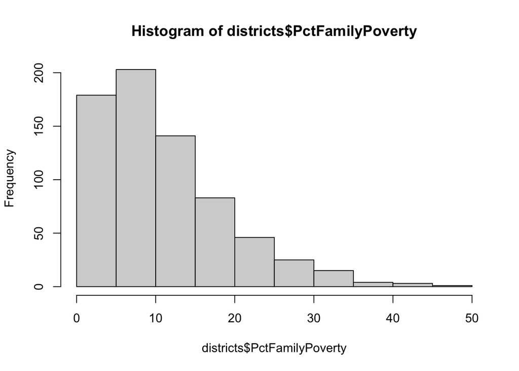

```r
hist(districts$PctFamilyPoverty)
```

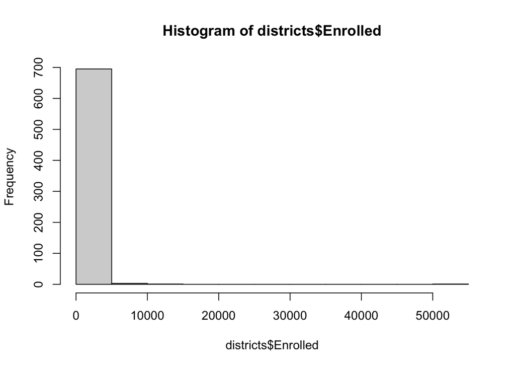

```r
hist(districts$Enrolled) # 3
```

## Transforming Variables Prior to Inferential Analysis

Based on the histograms you created above, you may want to make some transformations to your numeric variables to reshape their respective distributions. Remember to add new variables to your dataset, rather than overwriting existing variables.

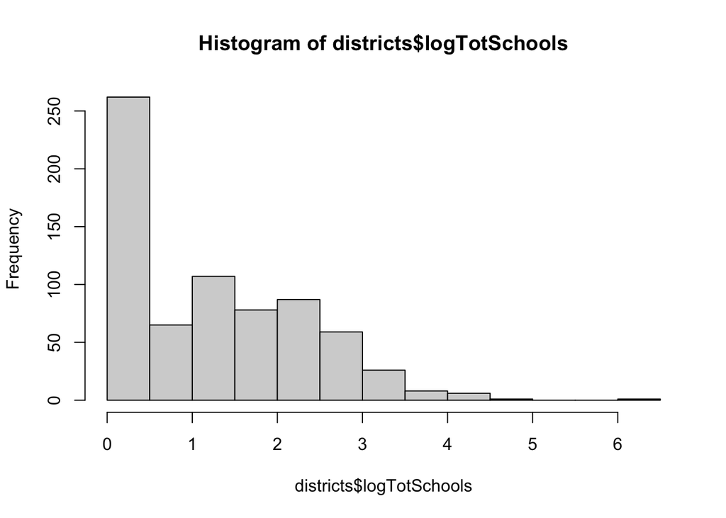

```r
# Here's an example: The total number of schools in each district is generally small
# but there are a few large districts. Try a log() transformation to address this.
districts$logTotSchools <- log(districts$TotalSchools)
hist(districts$logTotSchools)
```

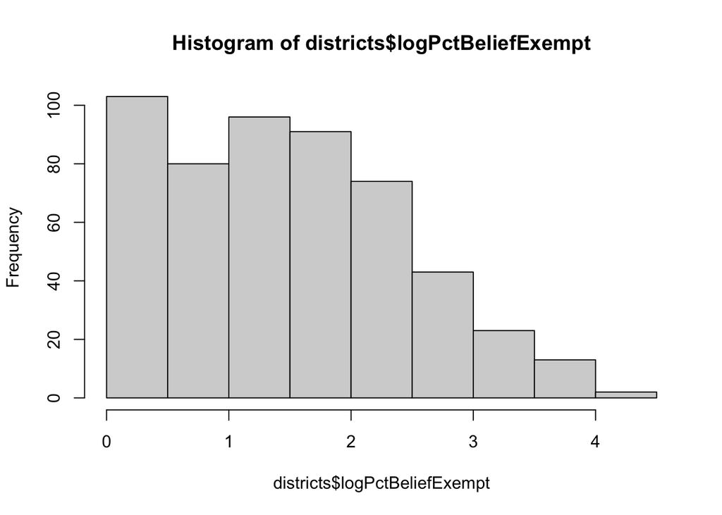

```r
# Add any additional transformations that you want to compute and store on your data set.
# Generally speaking, you should inspect the results of each transformation with a histogram
# or some descriptive statistics.

districts$logPctBeliefExempt <- log(districts$PctBeliefExempt)
hist(districts$logPctBeliefExempt)
```

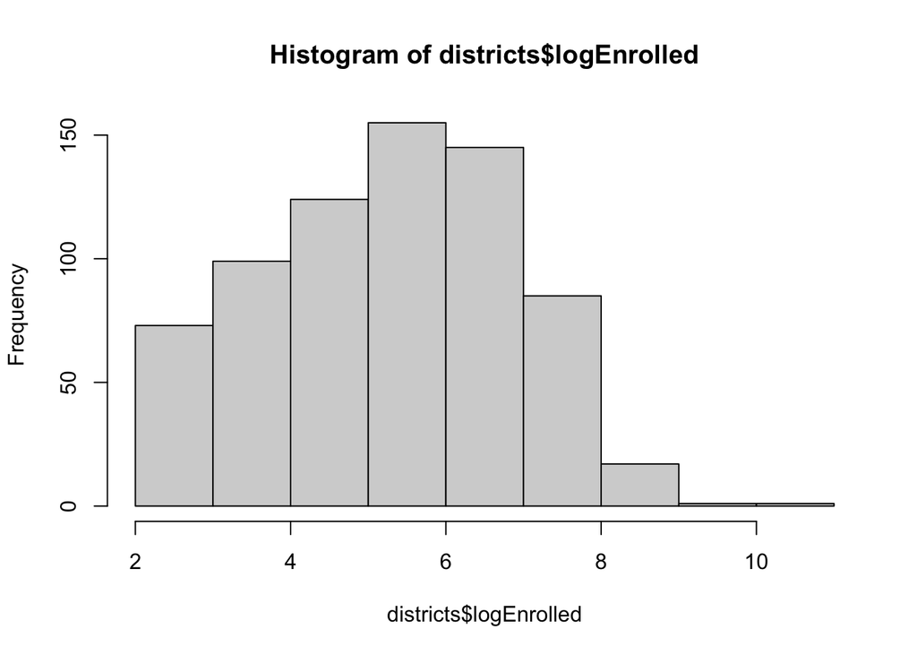

```r
districts$logEnrolled <- log(districts$Enrolled)
hist(districts$logEnrolled)
```

## Inferential Analyses

One very important aspect of doing this final exam is that you need to anticipate what kinds of analytical results will go into your report. Now is a good time to reexamine the exam specification to make sure that you know what analyses you will need in order to complete your report. For example, the following code produces results for a t-test which you may or may not need. Subsequent code blocks create linear regression and logistic regression results. Add any additional t-tests that you think you may need in this block of code.

```r
library(BayesFactor)
# These t-tests compare the mean number of schools per district for those
# districts that completed reporting versus those that did not.
t.test(TotalSchools ~ DistrictComplete, data=districts)
```

```
##
##  Welch Two Sample t-test
##
## data:  TotalSchools by DistrictComplete
## t = 1.5833, df = 42.065, p-value = 0.1208
## alternative hypothesis: true difference in means is not equal to 0
## 95 percent confidence interval:
##  -5.848455 48.456150
## sample estimates:
## mean in group FALSE  mean in group TRUE
##           27.302326            5.998478
```

```r
ttestBF(formula=TotalSchools ~ DistrictComplete, data=districts, posterior=FALSE)
```

```
## Bayes factor analysis
## --------------
## [1] Alt., r=0.707 : 713585.7 ±0%
##
## Against denominator:
##   Null, mu1-mu2 = 0
## ---
## Bayes factor type: BFindepSample, JZS
```

```r
summary(ttestBF(formula=TotalSchools ~ DistrictComplete, data=districts, posterior=TRUE, iterations=10000))
```

```
##
## Iterations = 1:10000
## Thinning interval = 1
## Number of chains = 1
## Sample size per chain = 10000
##
## 1. Empirical mean and standard deviation for each variable,
##    plus standard error of the mean:
##
##                         Mean       SD Naive SE Time-series SE
## mu                   16.2727   1.8727 0.018727       0.052606
## beta (FALSE - TRUE)  20.4356   3.7274 0.037274       0.105824
## sig2                556.4236  29.8436 0.298436       0.303305
## delta                 0.8673   0.1602 0.001602       0.004497
## g                     8.2375 171.8723 1.718723       1.718723
##
## 2. Quantiles for each variable:
##
##                         2.5%      25%      50%      75%   97.5%
## mu                   12.5131  15.0301  16.2874  17.5226  19.926
## beta (FALSE - TRUE)  13.0850  17.9314  20.3977  22.9405  27.710
## sig2                500.5851 535.8642 555.4818 575.8643 616.909
## delta                 0.5527   0.7600   0.8666   0.9748   1.183
## g                     0.1508   0.4439   0.9146   2.1724  24.114
```

```r
# Add any additional t-tests that you wish to compute.
```

```r
summary(lm(PctUpToDate ~ WithoutDTP+WithoutMMR+WithoutHepB+WithoutPolio+PctBeliefExempt, data=districts))
```

```
##
## Call:
## lm(formula = PctUpToDate ~ WithoutDTP + WithoutMMR + WithoutHepB +
##     WithoutPolio + PctBeliefExempt, data = districts)
##
## Residuals:
##     Min      1Q  Median      3Q     Max
## -43.543  -0.380   0.493   1.053   9.619
##
## Coefficients:
##                 Estimate Std. Error t value Pr(>|t|)
## (Intercept)     99.18542    0.14983 661.974  < 2e-16 ***
## WithoutDTP      -0.55934    0.06385  -8.761  < 2e-16 ***
## WithoutMMR      -0.73858    0.04690 -15.747  < 2e-16 ***
## WithoutHepB     -0.09799    0.03935  -2.490  0.01300 *
## WithoutPolio     0.15021    0.05755   2.610  0.00925 **
## PctBeliefExempt  0.21596    0.03252   6.641 6.28e-11 ***
## ---
## Signif. codes:  0 '***' 0.001 '**' 0.01 '*' 0.05 '.' 0.1 ' ' 1
##
## Residual standard error: 2.858 on 694 degrees of freedom
## Multiple R-squared:  0.9444, Adjusted R-squared:  0.944
## F-statistic:  2359 on 5 and 694 DF,  p-value: < 2.2e-16
```

```r
library(BayesFactor)


# These regressions predict the percentage of students who are up to date on vaccines
# using the number of students enrolled in the district.
summary(lm(PctBeliefExempt ~ logEnrolled+PctChildPoverty+PctFamilyPoverty+logTotSchools, data=districts))
```

```
##
## Call:
## lm(formula = PctBeliefExempt ~ logEnrolled + PctChildPoverty +
##     PctFamilyPoverty + logTotSchools, data = districts)
##
## Residuals:
##     Min      1Q  Median      3Q     Max
## -14.322  -3.849  -1.375   1.283  48.574
##
## Coefficients:
##                  Estimate Std. Error t value Pr(>|t|)
## (Intercept)      21.10150    1.96154  10.758  < 2e-16 ***
## logEnrolled      -2.88649    0.48009  -6.012 2.95e-09 ***
## PctChildPoverty  -0.03337    0.04991  -0.669  0.50395
## PctFamilyPoverty -0.18858    0.07474  -2.523  0.01185 *
## logTotSchools     2.16826    0.65815   3.294  0.00104 **
## ---
## Signif. codes:  0 '***' 0.001 '**' 0.01 '*' 0.05 '.' 0.1 ' ' 1
##
## Residual standard error: 7.859 on 695 degrees of freedom
## Multiple R-squared:  0.1437, Adjusted R-squared:  0.1387
## F-statistic: 29.15 on 4 and 695 DF,  p-value: < 2.2e-16
```

```r
summary(lmBF(PctBeliefExempt ~ logEnrolled+PctChildPoverty+PctFamilyPoverty+logTotSchools, data=districts, posterior=FALSE))
```

```
## Bayes factor analysis
## --------------
## [1] logEnrolled + PctChildPoverty + PctFamilyPoverty + logTotSchools : 1.628528e+19 ±0.01%
##
## Against denominator:
##   Intercept only
## ---
## Bayes factor type: BFlinearModel, JZS
```

```r
summary(lmBF(PctBeliefExempt ~ logEnrolled+PctChildPoverty+PctFamilyPoverty+logTotSchools, data=districts, posterior=TRUE, iterations=10000))
```

```
##
## Iterations = 1:10000
## Thinning interval = 1
## Number of chains = 1
## Sample size per chain = 10000
##
## 1. Empirical mean and standard deviation for each variable,
##    plus standard error of the mean:
##
##                      Mean      SD  Naive SE Time-series SE
## mu                5.48954 0.29856 0.0029856      0.0029304
## logEnrolled      -2.81604 0.47472 0.0047472      0.0047472
## PctChildPoverty  -0.03301 0.04893 0.0004893      0.0004893
## PctFamilyPoverty -0.18347 0.07316 0.0007316      0.0007316
## logTotSchools     2.11467 0.64987 0.0064987      0.0064987
## sig2             61.79512 3.29658 0.0329658      0.0336253
## g                 0.09449 0.10420 0.0010420      0.0010343
##
## 2. Quantiles for each variable:
##
##                      2.5%      25%      50%       75%    97.5%
## mu                4.90226  5.28408  5.48829  5.691020  6.06651
## logEnrolled      -3.75746 -3.13241 -2.81249 -2.494599 -1.89046
## PctChildPoverty  -0.12791 -0.06584 -0.03317 -0.001201  0.06554
## PctFamilyPoverty -0.32919 -0.23214 -0.18301 -0.133737 -0.04006
## logTotSchools     0.84500  1.67760  2.11471  2.542973  3.41014
## sig2             55.63319 59.53264 61.71413 63.846187 68.64216
## g                 0.02195  0.04367  0.06698  0.107233  0.33843
```

```r
# Add any additional regression analyses that you wish to compute
```

```r
summary(lm(PctUpToDate ~ logEnrolled+PctChildPoverty+PctFamilyPoverty+logTotSchools, data=districts))
```

```
##
## Call:
## lm(formula = PctUpToDate ~ logEnrolled + PctChildPoverty + PctFamilyPoverty +
##     logTotSchools, data = districts)
##
## Residuals:
##     Min      1Q  Median      3Q     Max
## -63.039  -3.923   2.050   6.430  23.638
##
## Coefficients:
##                  Estimate Std. Error t value Pr(>|t|)
## (Intercept)      64.99469    2.78737  23.318  < 2e-16 ***
## logEnrolled       4.24160    0.68220   6.217 8.71e-10 ***
## PctChildPoverty   0.07655    0.07092   1.079 0.280811
## PctFamilyPoverty  0.24715    0.10620   2.327 0.020243 *
## logTotSchools    -3.28317    0.93523  -3.511 0.000476 ***
## ---
## Signif. codes:  0 '***' 0.001 '**' 0.01 '*' 0.05 '.' 0.1 ' ' 1
##
## Residual standard error: 11.17 on 695 degrees of freedom
## Multiple R-squared:  0.1501, Adjusted R-squared:  0.1452
## F-statistic: 30.68 on 4 and 695 DF,  p-value: < 2.2e-16
```

```r
summary(lmBF(PctUpToDate ~ logEnrolled+PctChildPoverty+PctFamilyPoverty+logTotSchools, data= districts, posterior=FALSE))
```

```
## Bayes factor analysis
## --------------
## [1] logEnrolled + PctChildPoverty + PctFamilyPoverty + logTotSchools : 2.090227e+20 ±0.01%
##
## Against denominator:
##   Intercept only
## ---
## Bayes factor type: BFlinearModel, JZS
```

```r
summary(lmBF(PctUpToDate ~ logEnrolled+PctChildPoverty+PctFamilyPoverty+logTotSchools, data=districts, posterior=TRUE, iterations=10000))
```

```
##
## Iterations = 1:10000
## Thinning interval = 1
## Number of chains = 1
## Sample size per chain = 10000
##
## 1. Empirical mean and standard deviation for each variable,
##    plus standard error of the mean:
##
##                      Mean      SD  Naive SE Time-series SE
## mu                88.0904 0.41685 0.0041685      0.0041036
## logEnrolled        4.1469 0.68386 0.0068386      0.0068386
## PctChildPoverty    0.0739 0.06997 0.0006997      0.0006997
## PctFamilyPoverty   0.2425 0.10447 0.0010447      0.0010447
## logTotSchools     -3.2134 0.93795 0.0093795      0.0093795
## sig2             124.8453 6.73769 0.0673769      0.0673769
## g                  0.0997 0.12798 0.0012798      0.0012798
##
## 2. Quantiles for each variable:
##
##                       2.5%       25%       50%      75%    97.5%
## mu                87.27134  87.80584  88.09209  88.3726  88.9056
## logEnrolled        2.81085   3.67736   4.15173   4.6056   5.4980
## PctChildPoverty   -0.06361   0.02711   0.07311   0.1207   0.2107
## PctFamilyPoverty   0.03676   0.17314   0.24205   0.3114   0.4482
## logTotSchools     -5.03905  -3.85988  -3.20773  -2.5877  -1.3663
## sig2             112.17459 120.23838 124.55854 129.1754 138.6664
## g                  0.02295   0.04523   0.06909   0.1127   0.3546
```

```r
lm(PctUpToDate ~ PctChildPoverty*Enrolled, data = districts)
```

```
##
## Call:
## lm(formula = PctUpToDate ~ PctChildPoverty * Enrolled, data = districts)
##
## Coefficients:
##              (Intercept)           PctChildPoverty                  Enrolled
##                81.031570                  0.279300                  0.004992
## PctChildPoverty:Enrolled
##                -0.000157
```

```r
lm(PctUpToDate ~ PctChildPoverty+Enrolled, data = districts)
```

```
##
## Call:
## lm(formula = PctUpToDate ~ PctChildPoverty + Enrolled, data = districts)
##
## Coefficients:
##     (Intercept)  PctChildPoverty         Enrolled
##       8.320e+01        2.113e-01        2.823e-04
```

```r
lmBF(PctUpToDate ~ PctChildPoverty*Enrolled, data=districts, posterior=FALSE)
```

```
## Bayes factor analysis
## --------------
## [1] PctChildPoverty * Enrolled : 23154846 ±0%
##
## Against denominator:
##   Intercept only
## ---
## Bayes factor type: BFlinearModel, JZS
```

```r
lmBF(PctUpToDate ~ PctChildPoverty+Enrolled, data=districts, posterior=FALSE)
```

```
## Bayes factor analysis
## --------------
## [1] PctChildPoverty + Enrolled : 171779.7 ±0%
##
## Against denominator:
##   Intercept only
## ---
## Bayes factor type: BFlinearModel, JZS
```

```r
summary(lmBF(PctUpToDate ~ logEnrolled+PctChildPoverty+PctFamilyPoverty+logTotSchools, data=districts, posterior=FALSE))
```

```
## Bayes factor analysis
## --------------
## [1] logEnrolled + PctChildPoverty + PctFamilyPoverty + logTotSchools : 2.090227e+20 ±0.01%
##
## Against denominator:
##   Intercept only
## ---
## Bayes factor type: BFlinearModel, JZS
```

```r
summary(lmBF(PctUpToDate ~ logEnrolled+PctChildPoverty+PctFamilyPoverty+logTotSchools, data=districts, posterior=TRUE, iterations=10000))
```

```
##
## Iterations = 1:10000
## Thinning interval = 1
## Number of chains = 1
## Sample size per chain = 10000
##
## 1. Empirical mean and standard deviation for each variable,
##    plus standard error of the mean:
##
##                       Mean      SD  Naive SE Time-series SE
## mu                88.10132 0.41963 0.0041963      0.0041963
## logEnrolled        4.14159 0.67933 0.0067933      0.0067933
## PctChildPoverty    0.07486 0.07114 0.0007114      0.0007114
## PctFamilyPoverty   0.24078 0.10485 0.0010485      0.0010239
## logTotSchools     -3.20371 0.92223 0.0092223      0.0092223
## sig2             124.90583 6.78886 0.0678886      0.0690074
## g                  0.09850 0.11705 0.0011705      0.0011705
##
## 2. Quantiles for each variable:
##
##                       2.5%       25%       50%      75%    97.5%
## mu                87.27211  87.82425  88.09905  88.3800  88.9262
## logEnrolled        2.82382   3.68727   4.13098   4.5947   5.4683
## PctChildPoverty   -0.06279   0.02770   0.07461   0.1220   0.2117
## PctFamilyPoverty   0.03501   0.17002   0.24066   0.3124   0.4450
## logTotSchools     -5.04055  -3.80571  -3.19863  -2.5670  -1.4244
## sig2             112.57282 120.26765 124.60743 129.1504 138.8435
## g                  0.02257   0.04446   0.06846   0.1118   0.3454
```

```r
library(MCMCpack)
# These logistic regressions predict whether a district's reporting is complete
# based on the percentage of students who did not get the DTP vaccine.
glmOut <- glm(DistrictComplete ~ PctFamilyPoverty+logEnrolled+ logTotSchools , family = binomial(), data=districts)
summary(glmOut)
```

```
##
## Call:
## glm(formula = DistrictComplete ~ PctFamilyPoverty + logEnrolled +
##     logTotSchools, family = binomial(), data = districts)
##
## Deviance Residuals:
##     Min       1Q   Median       3Q      Max
## -3.0307   0.1239   0.2299   0.3549   1.6506
##
## Coefficients:
##                  Estimate Std. Error z value Pr(>|z|)
## (Intercept)      -1.69397    1.14046  -1.485  0.13745
## PctFamilyPoverty -0.05691    0.02126  -2.677  0.00744 **
## logEnrolled       1.83249    0.34452   5.319 1.04e-07 ***
## logTotSchools    -3.19901    0.51350  -6.230 4.67e-10 ***
## ---
## Signif. codes:  0 '***' 0.001 '**' 0.01 '*' 0.05 '.' 0.1 ' ' 1
##
## (Dispersion parameter for binomial family taken to be 1)
##
##     Null deviance: 323.23  on 699  degrees of freedom
## Residual deviance: 250.89  on 696  degrees of freedom
## AIC: 258.89
##
## Number of Fisher Scoring iterations: 7
```

```r
exp(coef(glmOut))
```

```
##      (Intercept) PctFamilyPoverty      logEnrolled    logTotSchools
##       0.18378782       0.94468084       6.24940402       0.04080251
```

```r
exp(confint(glmOut))
```

```
##                       2.5 %     97.5 %
## (Intercept)      0.01910868  1.7330416
## PctFamilyPoverty 0.90626194  0.9855952
## logEnrolled      3.25867066 12.7000560
## logTotSchools    0.01398595  0.1058881
```

```r
glmBayesOut <- MCMCpack::MCMClogit(DistrictComplete ~ PctFamilyPoverty+logEnrolled+ logTotSchools, data=districts)
summary(glmBayesOut)
```

```
##
## Iterations = 1001:11000
## Thinning interval = 1
## Number of chains = 1
## Sample size per chain = 10000
##
## 1. Empirical mean and standard deviation for each variable,
##    plus standard error of the mean:
##
##                      Mean      SD  Naive SE Time-series SE
## (Intercept)      -1.69530 1.17885 0.0117885      0.0445020
## PctFamilyPoverty -0.05704 0.02127 0.0002127      0.0007517
## logEnrolled       1.86021 0.35879 0.0035879      0.0134591
## logTotSchools    -3.26066 0.53248 0.0053248      0.0197820
##
## 2. Quantiles for each variable:
##
##                     2.5%     25%      50%      75%   97.5%
## (Intercept)      -4.0479 -2.4551 -1.69335 -0.91030  0.5842
## PctFamilyPoverty -0.0992 -0.0711 -0.05716 -0.04287 -0.0147
## logEnrolled       1.1717  1.6054  1.84388  2.10446  2.6030
## logTotSchools    -4.3559 -3.6309 -3.23758 -2.88637 -2.2452
```

```r
summary(exp(glmBayesOut))
```

```
##
## Iterations = 1001:11000
## Thinning interval = 1
## Number of chains = 1
## Sample size per chain = 10000
##
## 1. Empirical mean and standard deviation for each variable,
##    plus standard error of the mean:
##
##                     Mean      SD  Naive SE Time-series SE
## (Intercept)      0.37147 0.67566 0.0067566      0.0238977
## PctFamilyPoverty 0.94477 0.02009 0.0002009      0.0007097
## logEnrolled      6.85754 2.57772 0.0257772      0.0955173
## logTotSchools    0.04402 0.02381 0.0002381      0.0008796
##
## 2. Quantiles for each variable:
##
##                     2.5%     25%     50%     75%   97.5%
## (Intercept)      0.01746 0.08585 0.18390 0.40240  1.7935
## PctFamilyPoverty 0.90556 0.93137 0.94445 0.95804  0.9854
## logEnrolled      3.22747 4.97999 6.32101 8.20271 13.5048
## logTotSchools    0.01283 0.02649 0.03926 0.05578  0.1059
```

```r
# Add any additional logistic regression analyses that you wish to compute

glmOut <- glm(DistrictComplete ~ logEnrolled+ logTotSchools , family = binomial(), data=districts)
summary(glmOut)
```

```
##
## Call:
## glm(formula = DistrictComplete ~ logEnrolled + logTotSchools,
##     family = binomial(), data = districts)
##
## Deviance Residuals:
##     Min       1Q   Median       3Q      Max
## -3.0117   0.1267   0.2432   0.3638   1.6718
##
## Coefficients:
##               Estimate Std. Error z value Pr(>|z|)
## (Intercept)    -2.3652     1.1091  -2.133    0.033 *
## logEnrolled     1.8312     0.3454   5.301 1.15e-07 ***
## logTotSchools  -3.2085     0.5175  -6.199 5.67e-10 ***
## ---
## Signif. codes:  0 '***' 0.001 '**' 0.01 '*' 0.05 '.' 0.1 ' ' 1
##
## (Dispersion parameter for binomial family taken to be 1)
##
##     Null deviance: 323.23  on 699  degrees of freedom
## Residual deviance: 257.68  on 697  degrees of freedom
## AIC: 263.68
##
## Number of Fisher Scoring iterations: 7
```

```r
exp(coef(glmOut))
```

```
##   (Intercept)   logEnrolled logTotSchools
##    0.09393477    6.24159799    0.04041826
```

```r
exp(confint(glmOut))
```

```
##                    2.5 %     97.5 %
## (Intercept)   0.01030493  0.8296823
## logEnrolled   3.24519278 12.7049233
## logTotSchools 0.01375341  0.1059001
```

```r
glmBayesOut <- MCMCpack::MCMClogit(DistrictComplete ~ logEnrolled+ logTotSchools, data=districts)
summary(glmBayesOut)
```

```
##
## Iterations = 1001:11000
## Thinning interval = 1
## Number of chains = 1
## Sample size per chain = 10000
##
## 1. Empirical mean and standard deviation for each variable,
##    plus standard error of the mean:
##
##                 Mean     SD Naive SE Time-series SE
## (Intercept)   -2.410 1.1399 0.011399        0.03786
## logEnrolled    1.869 0.3537 0.003537        0.01174
## logTotSchools -3.285 0.5252 0.005252        0.01731
##
## 2. Quantiles for each variable:
##
##                 2.5%    25%    50%    75%   97.5%
## (Intercept)   -4.711 -3.152 -2.415 -1.638 -0.1884
## logEnrolled    1.215  1.620  1.865  2.096  2.5813
## logTotSchools -4.377 -3.618 -3.267 -2.911 -2.3161
```

```r
summary(exp(glmBayesOut))
```

```
##
## Iterations = 1001:11000
## Thinning interval = 1
## Number of chains = 1
## Sample size per chain = 10000
##
## 1. Empirical mean and standard deviation for each variable,
##    plus standard error of the mean:
##
##                  Mean      SD  Naive SE Time-series SE
## (Intercept)   0.16894 0.25016 0.0025016      0.0068919
## logEnrolled   6.90683 2.61940 0.0261940      0.0882999
## logTotSchools 0.04276 0.02255 0.0002255      0.0006998
##
## 2. Quantiles for each variable:
##
##                   2.5%     25%     50%    75%    97.5%
## (Intercept)   0.008995 0.04276 0.08933 0.1944  0.82828
## logEnrolled   3.369099 5.05530 6.45914 8.1318 13.21426
## logTotSchools 0.012561 0.02683 0.03810 0.0544  0.09865
```

## Knit, PDF, and Submit to Blackboard

Click the **Knit** button to create and inspect your html document. If the knitting process is successful an html file will be submitted to your current working directory. The file will also pop up in a viewer. There is a button on the viewer that says “Open in Browser.” Click this and then save a PDF version of your page from your browser. Submit the PDF version to Blackboard (Week 13 Content).